# Week 8

Gaussian Mixture Models & EM

Trang Thomas

2020-12-04 12:30:31

# EM using mclust –> GMM vs K means

# 1)

```r
data1<-read.csv('data1.csv')
data2<-read.csv('data2.csv')
library(ggpubr)
```

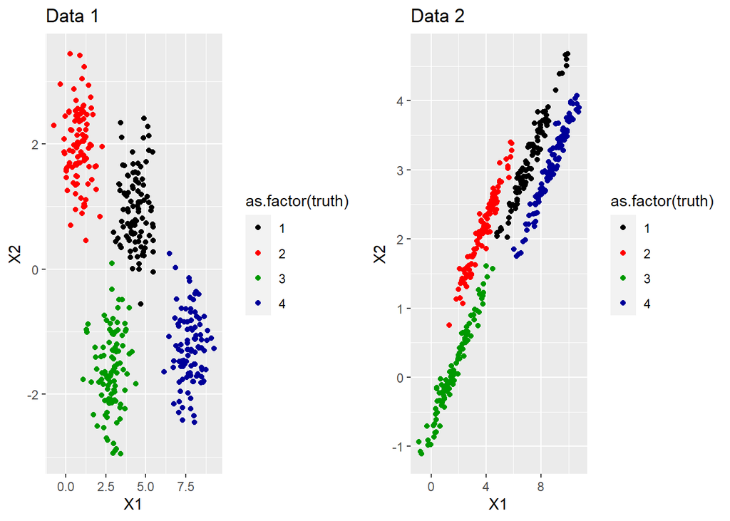

```r
gg1<-ggplot(data1, aes(X1,X2,color=as.factor(truth)))+geom_point()+scale_color_manual(values=c("#000000", "#FF0000", "#009900","#000099"))+ggtitle('Data 1')
gg2<-ggplot(data2, aes(X1,X2,color=as.factor(truth)), binwidth = 1)+geom_point()+scale_color_manual(values=c("#000000", "#FF0000", "#009900","#000099"))+ggtitle('Data 2')
ggarrange(gg1,gg2)
```

# 2)

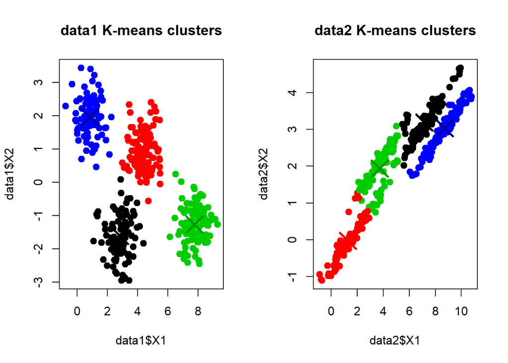

```r
par(mfrow=c(1,2))
km_data1=kmeans(data1,centers=4)
plot(data1$X1,data1$X2,col=km_data1$cluster,pch=19,cex=1.2,main='data1 K-means clusters')
points(km_data1$centers,pch=4,cex=3,lwd=3,col=c("#000000", "#FF0000", "#009900","#000099"))

km_data2=kmeans(data2,centers=4)
plot(data2$X1,data2$X2,col=km_data2$cluster,pch=19,cex=1.2,main='data2 K-means clusters')
points(km_data2$centers,pch=4,cex=3,lwd=3,col=c("#000000", "#FF0000", "#009900","#000099"))
```

We can see that apply the k means on the data 1 give the good result as in question 1  
But for data 2 the result given is not what we expected to have, because we have little differences on the definition of clusters As it is said in the reminder, “One way to think about the  
k-means model is that it places a circle (or, in higher dimensions, a hyper-sphere) at the center of each cluster, with a radius defined by the most distant point in the cluster” that explains why some clusters were not well classified

# 3)

```r
library(mclust)
```

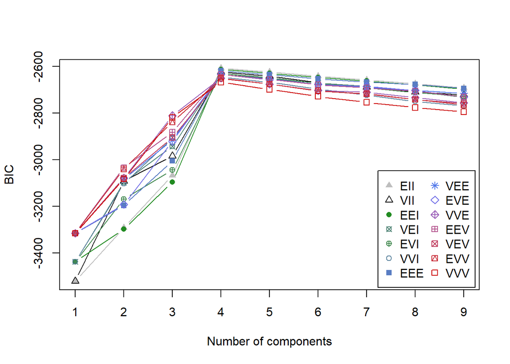

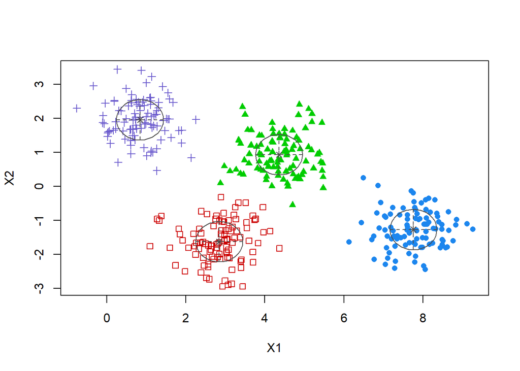

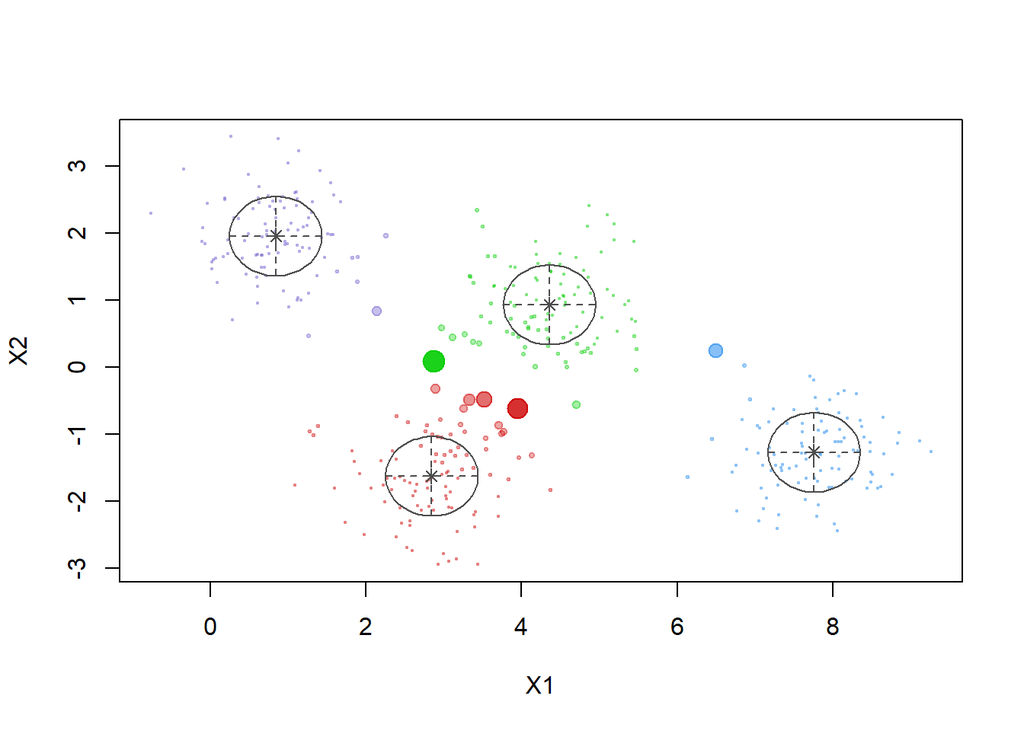

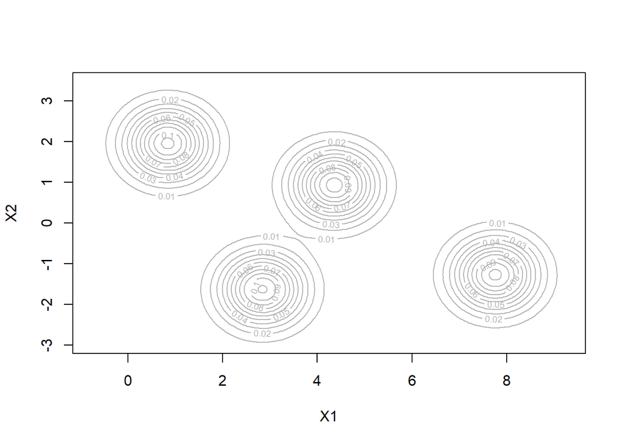

```r
mod1<-Mclust(data1[,1:2])
plot(mod1)
```

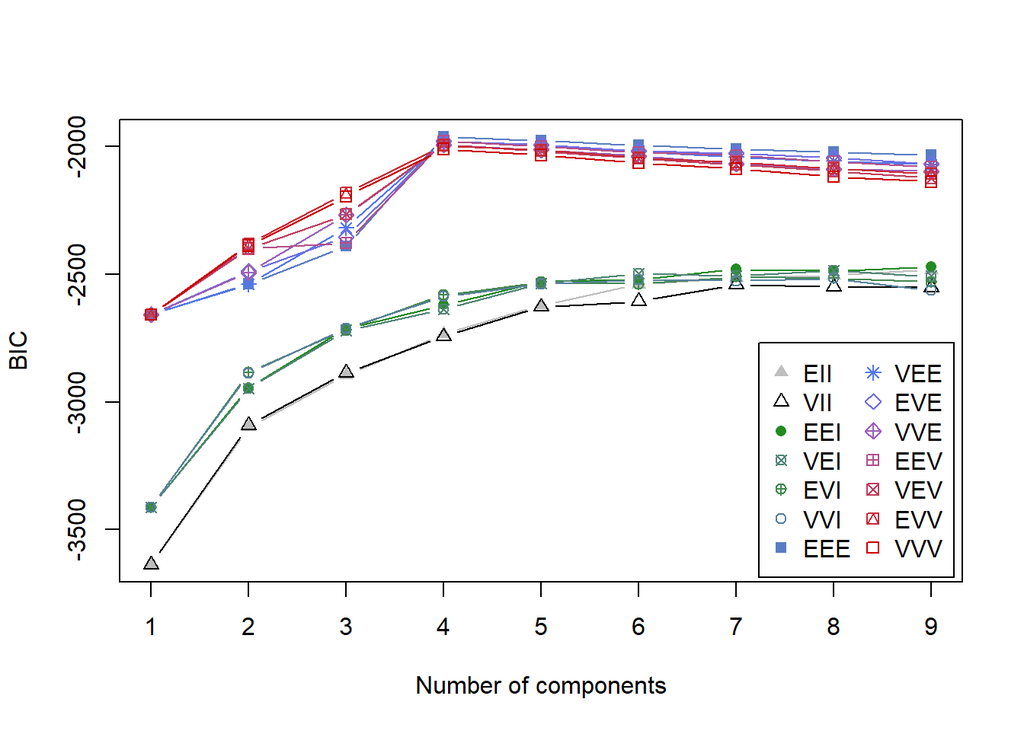

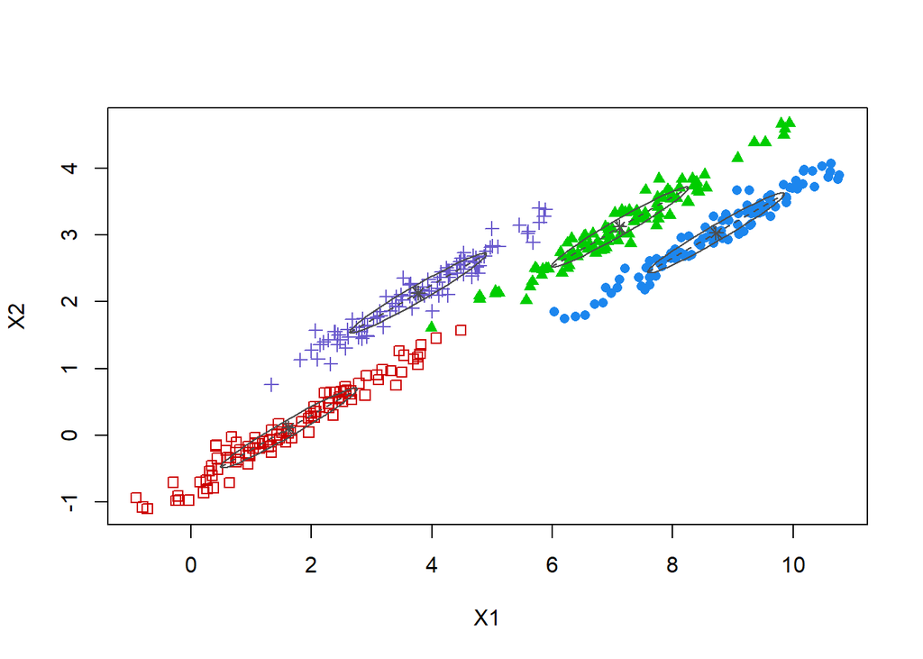

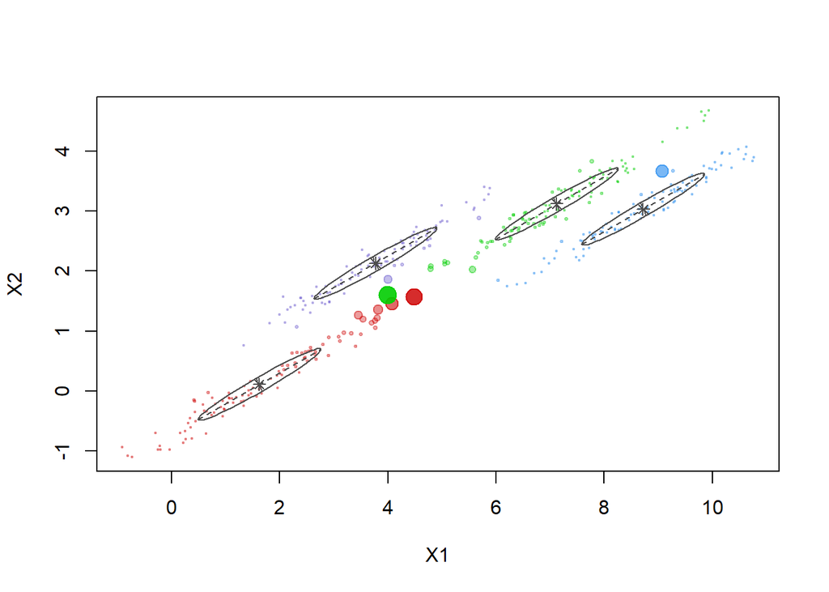

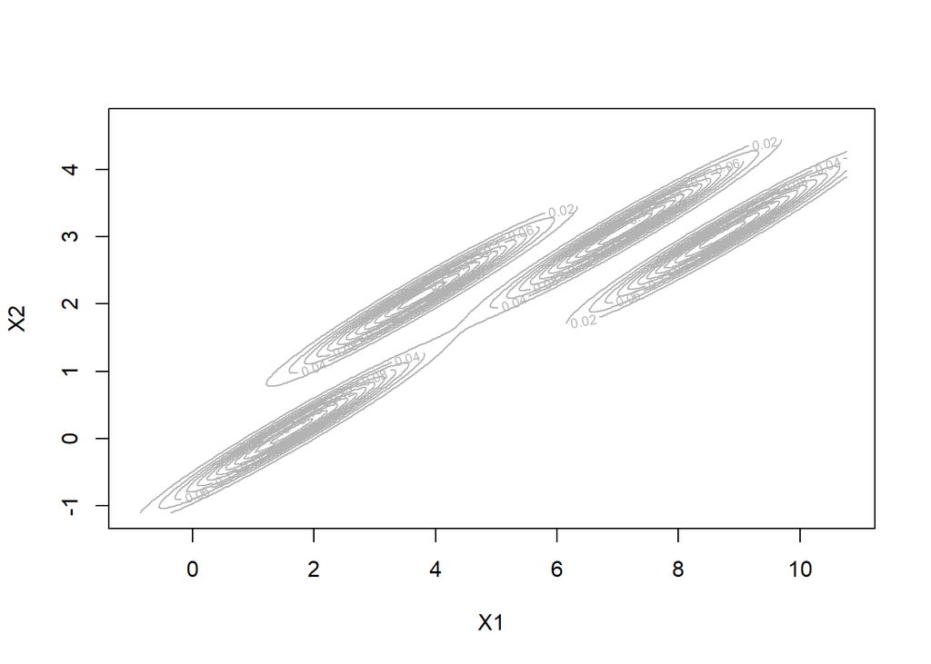

```r
mod2<-Mclust(data2[,1:2])
plot(mod2)
```

On the selection we have to choose between many options, we can type 1,2,3,4

# 4)

```r
summary(mod2)
```

```
## ----------------------------------------------------
## Gaussian finite mixture model fitted by EM algorithm
## ----------------------------------------------------
##
## Mclust EEE (ellipsoidal, equal volume, shape and orientation) model with 4
## components:
##
##  log-likelihood   n df       BIC       ICL
##       -938.8639 400 14 -1961.608 -1965.709
##
## Clustering table:
##   1   2   3   4
## 100  99 101 100
```

# 5)

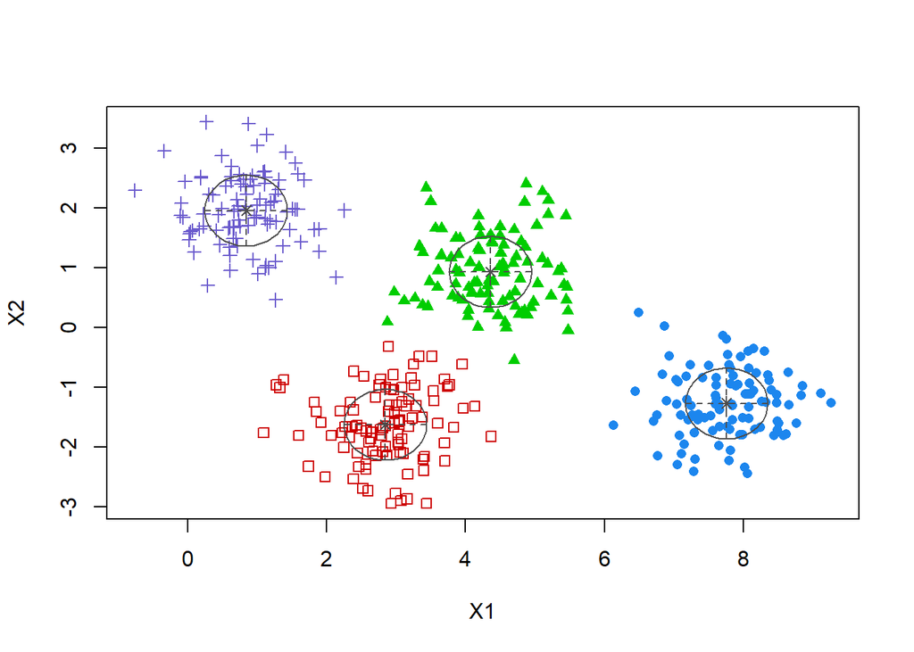

```r
plot(mod1, what = "classification")
```

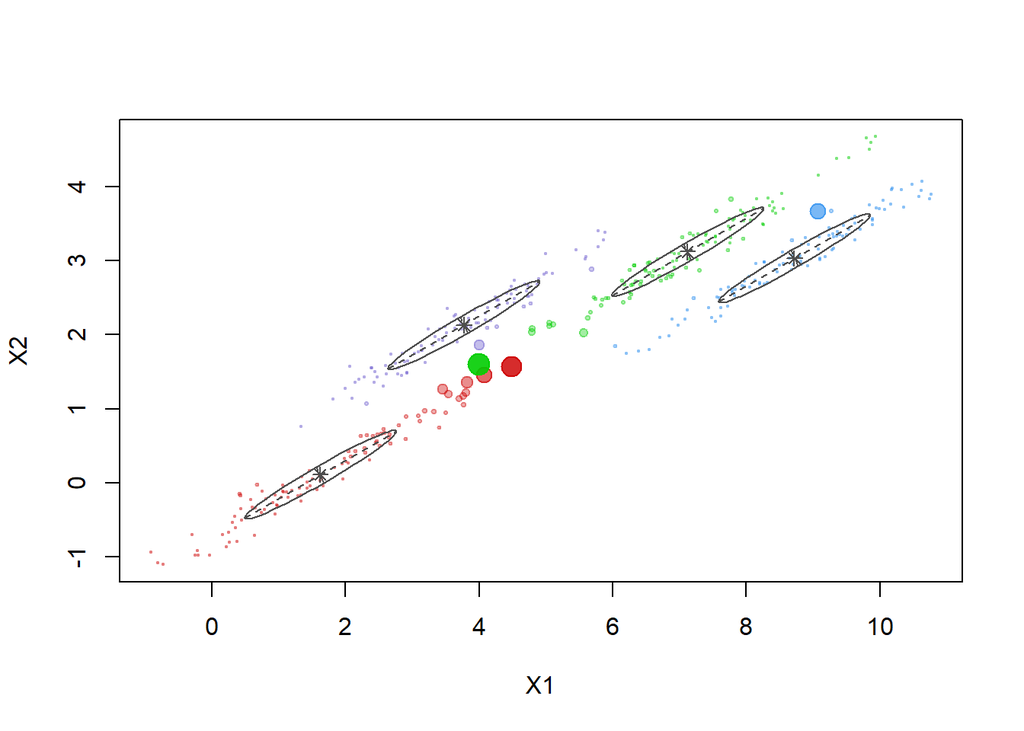

```r
plot(mod2, what = "uncertainty")
```

# 6)

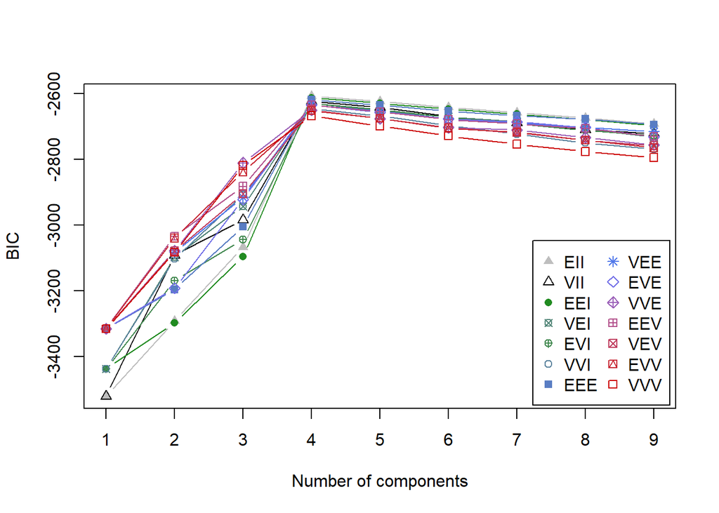

```r
plot(mod1, what = "BIC")
```

The plot shows the values of BIC according to the number of componenents, the highest value of BIC is for 4 components where all points are united and very close to each other.

# 7)

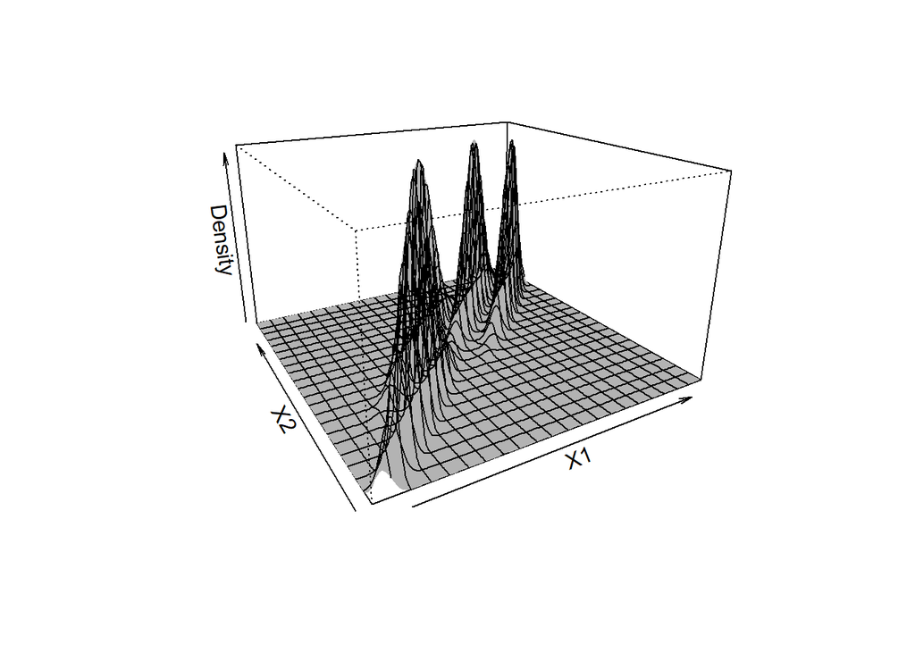

```r
dens<-densityMclust(data2[,1:2])
plot(dens,what='density', type='persp')
```

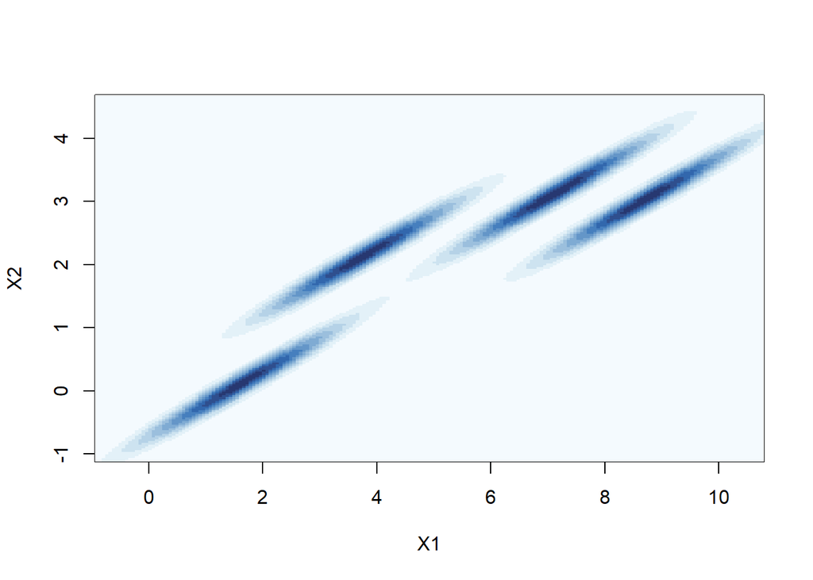

```r
plot(dens,what='density', type='image')
```

Density of X2 in function of X1

# EM on 1D

# 8)

```r
set.seed(1234)
gaussian1<-rnorm(100,mean=-5,sd=2)
part1 <- cbind(gaussian1, 1)
gaussian2<-rnorm(100,mean=0,sd=2)
part2 <- cbind(gaussian2, 2)
gaussian3<-rnorm(100,mean=5,sd=2)
part3 <- cbind(gaussian3, 3)

df<-rbind(part1,part2,part3)
df<-data.frame(df)
names(df)[1]<-'X'
names(df)[2]<-'source'
head(df)
```

|  | X | source |
| --- | --- | --- |
| 1 | -7.414131 | 1 |
| 2 | -4.445142 | 1 |
| 3 | -2.831118 | 1 |
| 4 | -9.691395 | 1 |
| 5 | -4.141751 | 1 |
| 6 | -3.987888 | 1 |

We have 3 groups of gaussian in our data frame

# 9)

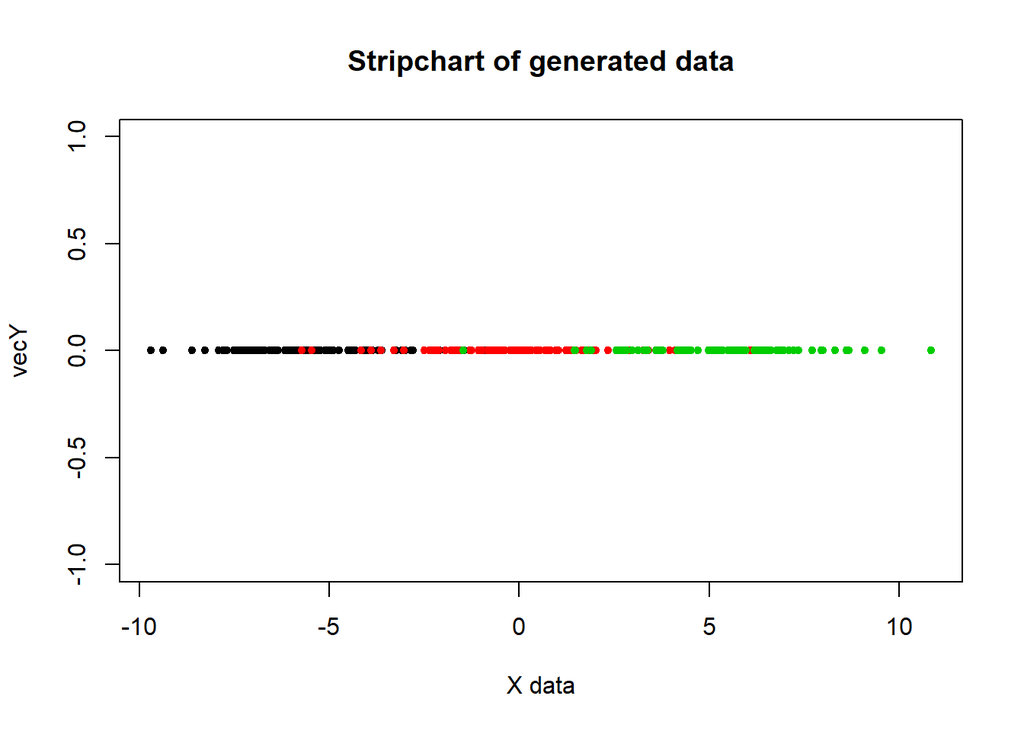

```r
#stripchart(df$X,col=df$source,pch=21,bg=1)

vecY=rep(0,300)
plot(x=df$X,y=vecY,col=df$source,pch=20,bg=2,xlab='X data',title('Stripchart of generated data'))
```

# 10)

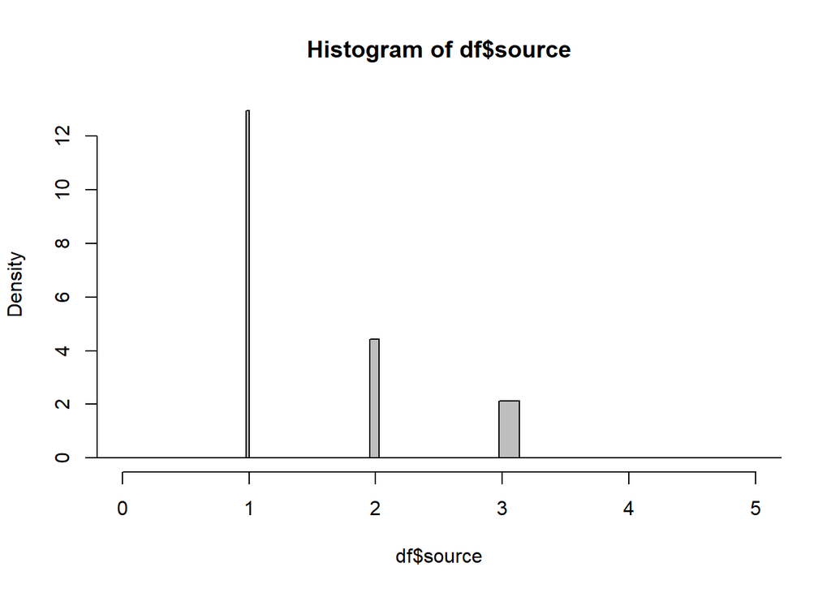

```r
hist(df$source,df$X,xlim=c(0,5),col='grey')
```

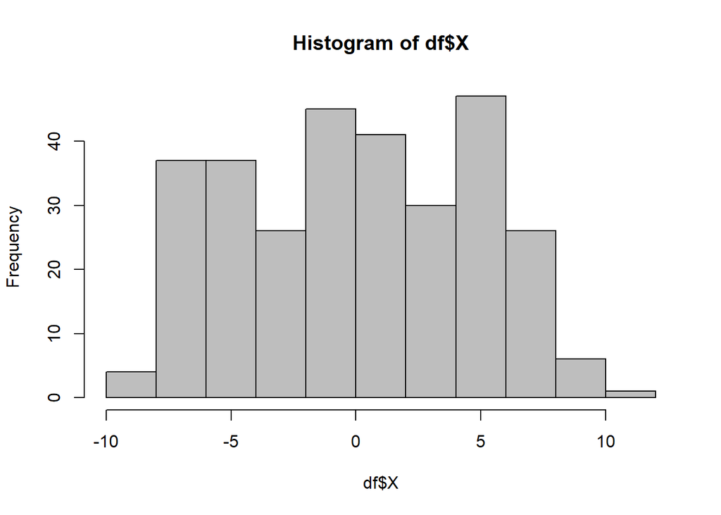

```r
p <-hist(df$X,col='grey')
```

# 11)

```r
gaussian1Bis<-rnorm(100,mean=-100,sd=2)
part1Bis <- cbind(gaussian1Bis, 1)
gaussian2Bis<-rnorm(100,mean=0,sd=2)
part2Bis <- cbind(gaussian2Bis, 2)
gaussian3Bis<-rnorm(100,mean=100,sd=2)
part3Bis <- cbind(gaussian3Bis, 3)

dfBis<-rbind(part1Bis,part2Bis,part3Bis)
dfBis<-data.frame(dfBis)
names(dfBis)[1]<-'X'
names(dfBis)[2]<-'source'
head(dfBis)
```

|  | X | source |
| --- | --- | --- |
| 1 | -101.15991 | 1 |
| 2 | -101.90656 | 1 |
| 3 | -100.35886 | 1 |
| 4 | -97.98038 | 1 |
| 5 | -99.95275 | 1 |
| 6 | -101.29806 | 1 |

```r
modGen<-Mclust(dfBis[,1])
summary(modGen)
```

```
## ----------------------------------------------------
## Gaussian finite mixture model fitted by EM algorithm
## ----------------------------------------------------
##
## Mclust E (univariate, equal variance) model with 3 components:
##
##  log-likelihood   n df       BIC       ICL
##       -971.9919 300  6 -1978.206 -1978.206
##
## Clustering table:
##   1   2   3
## 100 100 100
```

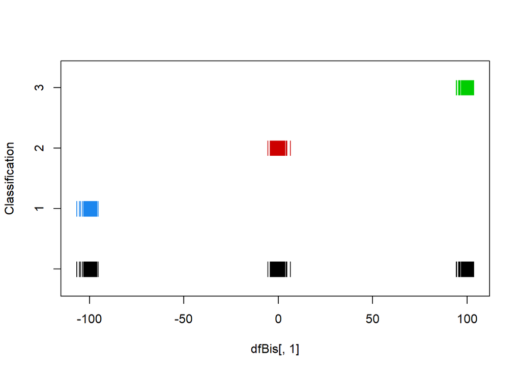

```r
plot(modGen, what = "classification")
```

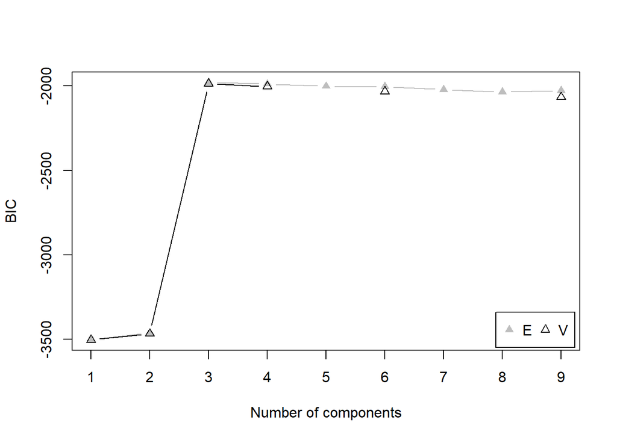

```r
plot(modGen, what = "BIC")
```

We created another df because gaussians were not different enough so the model couldn’t identify the clusters well. We have all of our 3 clusters which are well identified which a 100% identity  
For the BIC, We have the highest BIC with 3 components

# 12)

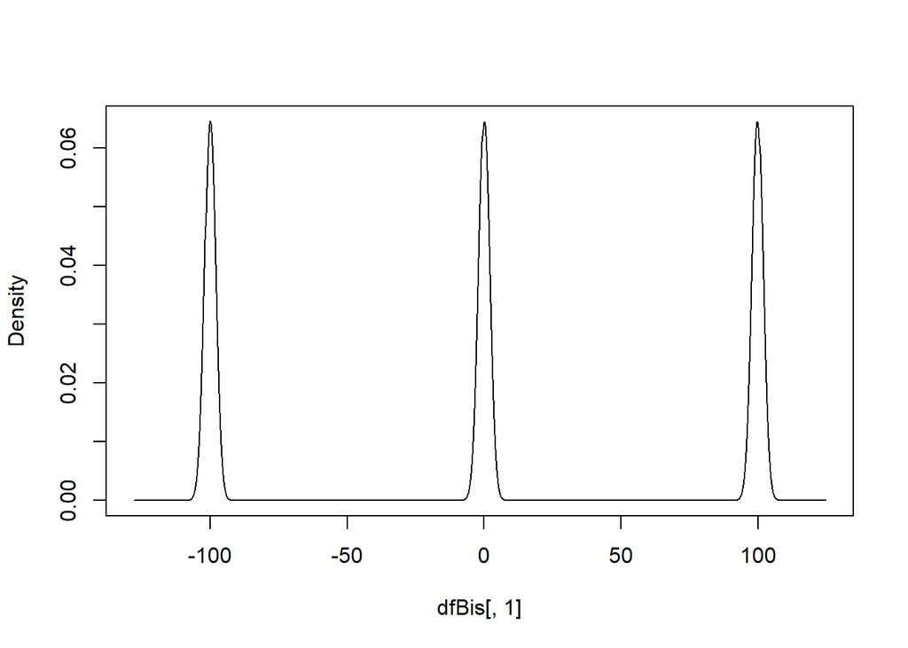

```r
densBis<-densityMclust(dfBis[,1])
plot(densBis,what='density', type='persp')
plot(densBis,what='density', type='image')
```

# 2.1)

```r
gaussian1Bis<-rnorm(100,mean=-100,sd=2)
part1Bis <- cbind(gaussian1Bis, 1)
gaussian2Bis<-rnorm(100,mean=0,sd=2)
part2Bis <- cbind(gaussian2Bis, 2)
gaussian3Bis<-rnorm(100,mean=100,sd=2)
part3Bis <- cbind(gaussian3Bis, 3)

dfBis<-rbind(part1Bis,part2Bis,part3Bis)
dfBis<-data.frame(dfBis)
```

The mixing coefficient seems to be the division of (number of point in the k-th cluster)/(total number of points) Let’s do the same datframe as previously

# 2.2)

```r
mixingProportions=c(1/3,1/3,1/3)
```

MixingProportion is the part of point of a cluster Identity matrices